# Regression Models Course Project

Francisco Martín

October 17, 2018

## Statement

You work for Motor Trend, a magazine about the automobile industry. Looking at a data set of a collection of cars, they are interested in exploring the relationship between a set of variables and miles per gallon (MPG) (outcome). They are particularly interested in the following two questions:

- “Is an automatic or manual transmission better for MPG”
- “Quantify the MPG difference between automatic and manual transmissions”

## Exploratory Analysis

First of all, we should load mtcars dataset into our workspace

```r
data(mtcars)
head(mtcars)
```

```
##                    mpg cyl disp  hp drat    wt  qsec vs am gear carb
## Mazda RX4         21.0   6  160 110 3.90 2.620 16.46  0  1    4    4
## Mazda RX4 Wag     21.0   6  160 110 3.90 2.875 17.02  0  1    4    4
## Datsun 710        22.8   4  108  93 3.85 2.320 18.61  1  1    4    1
## Hornet 4 Drive    21.4   6  258 110 3.08 3.215 19.44  1  0    3    1
## Hornet Sportabout 18.7   8  360 175 3.15 3.440 17.02  0  0    3    2
## Valiant           18.1   6  225 105 2.76 3.460 20.22  1  0    3    1
```

As we see, type of transmission is displayed in column “am”, where 1 means automatic and 0 means manual transmission. I don’t like how it looks, so I am going to change it to a factor column and see how data looks for each of one:

```r
mtcars_cool <- mtcars
mtcars_cool$am <- factor(mtcars$am, labels = c("manual","automatic"))
summary(mtcars_cool[mtcars_cool$am == "automatic",]$mpg)
```

```
##    Min. 1st Qu.  Median    Mean 3rd Qu.    Max.
##   15.00   21.00   22.80   24.39   30.40   33.90
```

```r
summary(mtcars_cool[mtcars_cool$am == "manual",]$mpg)
```

```
##    Min. 1st Qu.  Median    Mean 3rd Qu.    Max.
##   10.40   14.95   17.30   17.15   19.20   24.40
```

We can see mean value is about 7.24 more mpg in automatic than in manual (plot 1). We can adventure and do a big linear model looking for relations, but maybe it is better to look at correlations between different variables and mpg before doing any model:

```
##   mpg   cyl  disp    hp  drat    wt  qsec    vs    am  gear  carb
##  1.00 -0.85 -0.85 -0.78  0.68 -0.87  0.42  0.66  0.60  0.48 -0.55
```

There are four variables which have a stronger correlation. Those are “wt”, “cyl”, “disp” and “hp”. Let’s look how this variables and type of transmission affect on miles per galon doing different models:

```r
lm_1 <- lm(formula = mpg ~ am, data = mtcars)
lm_2 <- lm(formula = mpg ~ am + wt, data = mtcars)
lm_3 <- lm(formula = mpg ~ am + wt + cyl, data = mtcars)
lm_4 <- lm(formula = mpg ~ am + wt + cyl + disp, data = mtcars)
lm_5 <- lm(formula = mpg ~ am + wt + cyl + disp + hp, data = mtcars)
lm_all <- lm(formula = mpg ~ ., data = mtcars)
```

We have trained six models. Let’s compare all of them using anova:

```r
anova(lm_1, lm_2, lm_3, lm_4, lm_5, lm_all)
```

```
## Analysis of Variance Table
##
## Model 1: mpg ~ am
## Model 2: mpg ~ am + wt
## Model 3: mpg ~ am + wt + cyl
## Model 4: mpg ~ am + wt + cyl + disp
## Model 5: mpg ~ am + wt + cyl + disp + hp
## Model 6: mpg ~ cyl + disp + hp + drat + wt + qsec + vs + am + gear + carb
##   Res.Df    RSS Df Sum of Sq       F    Pr(>F)
## 1     30 720.90
## 2     29 278.32  1    442.58 63.0133 9.325e-08 ***
## 3     28 191.05  1     87.27 12.4257   0.00201 **
## 4     27 188.43  1      2.62  0.3732   0.54782
## 5     26 163.12  1     25.31  3.6030   0.07151 .
## 6     21 147.49  5     15.63  0.4449   0.81206
## ---
## Signif. codes:  0 '***' 0.001 '**' 0.01 '*' 0.05 '.' 0.1 ' ' 1
```

```r
lm_final <- lm(formula = mpg ~ am + wt + hp, data = mtcars)
summary(lm_final)
```

```
##
## Call:
## lm(formula = mpg ~ am + wt + hp, data = mtcars)
##
## Residuals:
##     Min      1Q  Median      3Q     Max
## -3.4221 -1.7924 -0.3788  1.2249  5.5317
##
## Coefficients:
##              Estimate Std. Error t value Pr(>|t|)
## (Intercept) 34.002875   2.642659  12.867 2.82e-13 ***
## am           2.083710   1.376420   1.514 0.141268
## wt          -2.878575   0.904971  -3.181 0.003574 **
## hp          -0.037479   0.009605  -3.902 0.000546 ***
## ---
## Signif. codes:  0 '***' 0.001 '**' 0.01 '*' 0.05 '.' 0.1 ' ' 1
##
## Residual standard error: 2.538 on 28 degrees of freedom
## Multiple R-squared:  0.8399, Adjusted R-squared:  0.8227
## F-statistic: 48.96 on 3 and 28 DF,  p-value: 2.908e-11
```

Looking at R-Squared term, it explains 83.99% of the variability. We can use this model to predict and explain general behaviour of mpg as we did in appendix (plots 2 and 3) doublechecking residuals and seing their are normally distributed.

## Apendix (figures)

### Plot 1 - BoxPlot of mpg per type of transmission

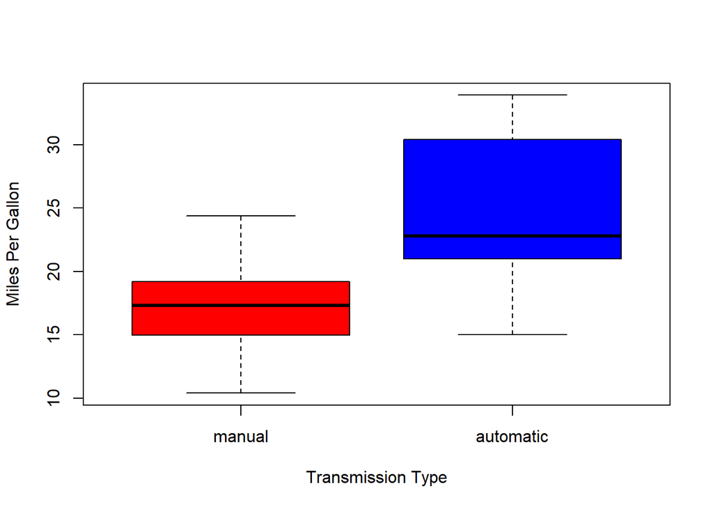

```r
boxplot(mpg ~ am, data = mtcars_cool, col = (c("red","blue")), ylab = "Miles Per Gallon", xlab = "Transmission Type")
```

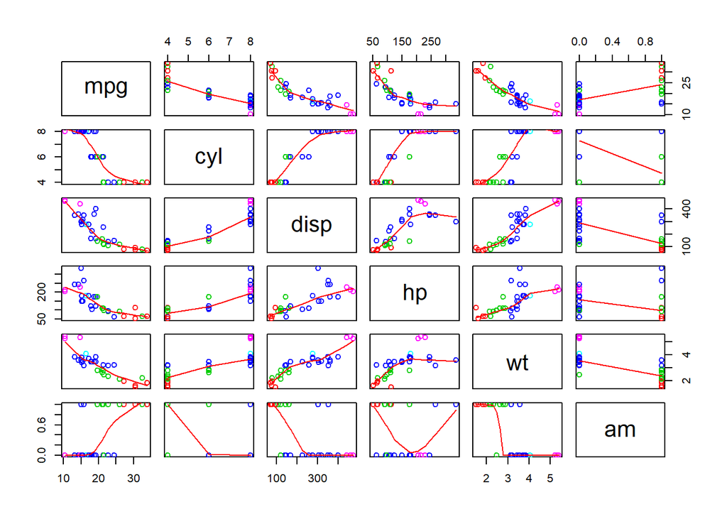

```r
mtcarsplot <- mtcars[,c(1,2,3,4,6,9)]
pairs(mtcarsplot, panel = panel.smooth, col = 9 + mtcarsplot$wt)
```

### Plot 3 - Plot of residuals in final model

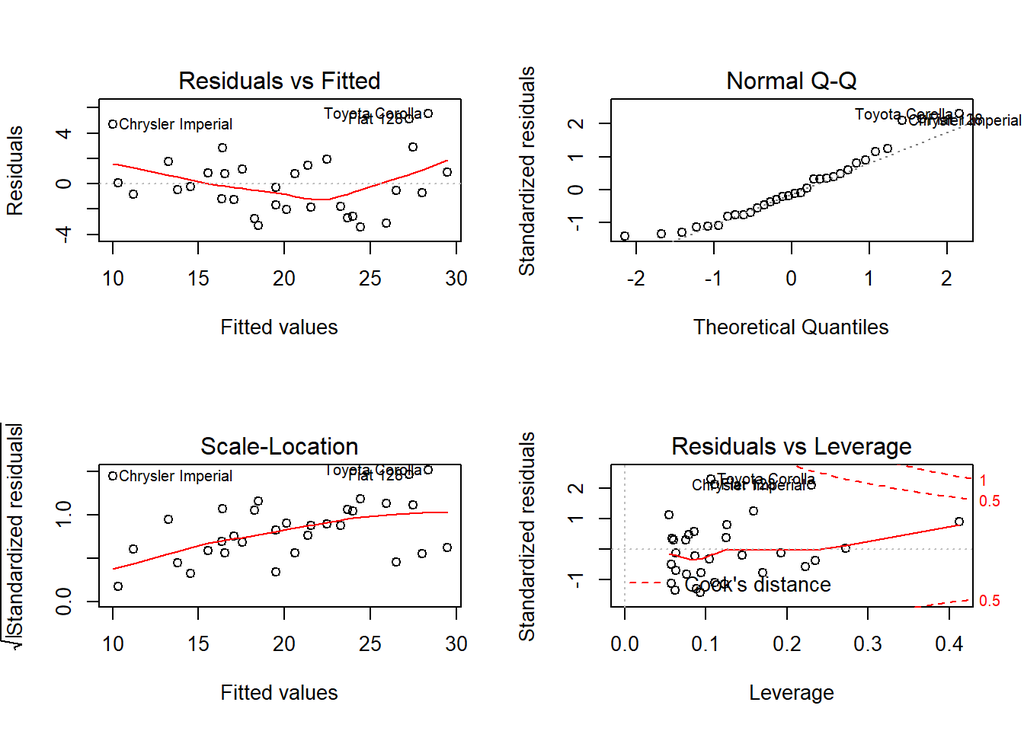

```r
par(mfrow = c(2,2))
plot(lm_final)
```